# Chinese text handling

## Overview

This vignette shows how to work with Chinese language materials using the corpus package. It’s based on Haiyan Wang’s [rOpenSci demo](https://github.com/ropensci/textworkshop17/tree/master/demos/chineseDemo) and assumes you have `httr`, `stringi`, and `wordcloud` installed.

We’ll start by loading the package and setting a seed to ensure reproducible results

```r
library("corpus")
set.seed(100)
```

## Documents and stopwords

First download a stop word list suitable for Chinese, the Baidu stop words

```r
cstops <- "https://raw.githubusercontent.com/ropensci/textworkshop17/master/demos/chineseDemo/ChineseStopWords.txt"
csw <- paste(readLines(cstops, encoding = "UTF-8"), collapse = "\n") # download
csw <- gsub("\\s", "", csw)           # remove whitespace
stop_words <- strsplit(csw, ",")[[1]] # extract the comma-separated words
```

Next, download some demonstration documents. These are in plain text format, encoded in UTF-8.

```r
gov_reports <- "https://api.github.com/repos/ropensci/textworkshop17/contents/demos/chineseDemo/govReports"
raw <- httr::GET(gov_reports)
paths <- sapply(httr::content(raw), function(x) x$path)
names <- tools::file_path_sans_ext(basename(paths))
urls <- sapply(httr::content(raw), function(x) x$download_url)
text <- sapply(urls, function(url) paste(readLines(url, warn = FALSE,
                                                   encoding = "UTF-8"),
                                         collapse = "\n"))
names(text) <- names
```

## Tokenization

Corpus does not know how to tokenize languages with no spaces between words. Fortunately, the ICU library (used internally by the `stringi` package) does, by using a dictionary of words along with information about their relative usage rates.

We use `stringi`’s tokenizer, collect a dictionary of the word types, and then manually insert zero-width spaces between tokens.

```r
toks <- stringi::stri_split_boundaries(text, type = "word")
dict <- unique(c(toks, recursive = TRUE)) # unique words
text2 <- sapply(toks, paste, collapse = "\u200b")
```

and put the input text in a corpus data frame for convenient analysis

```r
data <- corpus_frame(name = names, text = text2)
```

We then specify a token filter to determine what is counted by other corpus functions. Here we set `combine = dict` so that multi-word tokens get treated as single entities

```r
f <- text_filter(drop_punct = TRUE, drop = stop_words, combine = dict)
(text_filter(data) <- f) # set the text column's filter
```

```
Text filter with the following options:

    map_case: TRUE
    map_quote: TRUE
    remove_ignorable: TRUE
    combine:  chr [1:12033] "\n" "1954" "年" "政府" "工作" "报告" "—" ...
    stemmer: NULL
    stem_dropped: FALSE
    stem_except: NULL
    drop_letter: FALSE
    drop_number: FALSE
    drop_punct: TRUE
    drop_symbol: FALSE
    drop:  chr [1:717] "按" "按照" "俺" "俺们" "阿" "别" "别人" "别处" ...
    drop_except: NULL
    connector: _
    sent_crlf: FALSE
    sent_suppress:  chr [1:155] "A." "A.D." "a.m." "A.M." "A.S." "AA." ...
```

## Document statistics

We can now compute type, token, and sentence counts

```r
text_stats(data)
```

```
   tokens types sentences
1    8694  2023       453
2   21079  2780       981
3    9079  1342       495
4   13009  2334       704
5    9347  1973       412
6   11640  2263       577
7    3889  1128       164
8    7303  1697       387
9    2020   839       125
10  11935  2744       659
11  10652  2412       505
12   5634  1300       342
13  12464  2588       671
14  11867  2478       585
15   9018  2267       487
16   7187  1976       413
17   5714  1519       292
18  10540  2149       481
19   8694  1895       405
20  11830  2429       653
⋮  (49 rows total)
```

and examine term frequencies

```r
(stats <- term_stats(data))
```

```
   term count support
1  发展  5627      49
2  经济  5036      49
3  社会  4255      49
4  建设  4248      49
5  人民  2897      49
6  主义  2817      49
7  工作  2642      49
8  企业  2627      49
9  国家  2595      49
10 加强  2438      49
11 生产  2407      49
12 年    2021      49
13 我国  1999      49
14 提高  1947      49
15 中    1860      49
16 增长  1800      49
17 化    1740      49
18 继续  1670      49
19 技术  1586      49
20 工业  1580      49
⋮  (11612 rows total)
```

These operations all use the `text_filter(data)` value we set above to determine the token and sentence boundaries.

## Visualization

We can visualize word frequencies with a wordcloud. You may want to use a font suitable for Chinese (‘STSong’ is a good choice for Mac users). We switch to this font, create the wordcloud, then switch back.

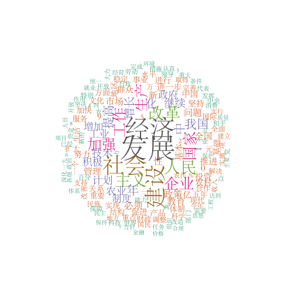

Word cloud

```r
font_family <- par("family") # the previous font family
par(family = "STSong") # change to a nice Chinese font
with(stats, {
    wordcloud::wordcloud(term, count, min.freq = 500,
                         random.order = FALSE, rot.per = 0.25,
                         colors = RColorBrewer::brewer.pal(8, "Dark2"))
})
```

```r
par(family = font_family) # switch the font back
```

## Co-occurrences

Here are the terms that show up in sentences containing a particular term

```r
sents <- text_split(data) # split text into sentences
subset <- text_subset(sents, '\u6539\u9769') # select those with the term
term_stats(subset) # count the word occurrences
```

```
   term count support
1  改革  2931    2457
2  发展   866     652
3  体制   768     649
4  经济  1016     639
5  推进   522     491
6  深化   473     469
7  社会   664     464
8  建设   513     391
9  制度   452     364
10 开放   389     353
11 企业   489     339
12 工作   301     268
13 积极   262     252
14 继续   260     251
15 管理   281     249
16 进行   239     232
17 加快   230     225
18 化     261     224
19 加强   248     224
20 主义   275     221
⋮  (3888 rows total)
```

The first term is the search query. It appears 2931 times in the corpus, in 2457 different sentences. The second term in the list appears in 652 of 2457 sentences containing the search term. (I don’t speak Chinese, but Google translate tells me that the search term is “reform”, and the second and third items in the list are “development” and “system”.)

## Keyword in context

Finally, here’s how we might show terms in their local context

```r
text_locate(data, "\u6027")
```

```
   text            before            instance             after
1  1     …业方面的重要问题之一是计划    性    不足。我们现在还有许多计划不…
2  1     …技术和提高劳动生产率的积极    性    ，对于发展经济建设很有害，因…
3  1     …分表现了人民群众的政治积极    性    和政治觉悟的提高，充分表现了…
4  1     …器、氢武器和其他大规模毁灭    性    武器的愿望必须满足。这些都是…
5  2     …众在劳动战线上的高度的积极    性    和创造性，依靠全国人民在改革…
6  2     …战线上的高度的积极性和创造    性    ，依靠全国人民在改革土地制度…
7  2     …，已经分得了土地，生产积极    性    很高，何必实行合作化呢？我们…
8  2     …觉悟，充分地发挥群众的积极    性    和创造性，提高劳动生产率。\n…
9  2     …分地发挥群众的积极性和创造    性    ，提高劳动生产率。\n\n　　我…
10 2     …必须照顾单干农户的生产积极    性    ，给单干农户以积极的帮助和领…
11 2     …重要办法。国家从缩减非生产    性    建设的支出和行政机关的经费等…
12 2     …，更重要的是发扬地方的积极    性    ，加强地方党政机关对农业的领…
13 2     …策，提高农民群众的生产积极    性    ，保证这个计划的实现。地方的…
14 2     …，刺激和发挥农民的经营积极    性    。\n\n　　有些农村的地方国家…
15 2     …设以后，为了加强生产的计划    性    ，对许多重要原料，有的由国家…
16 2     …进一步地提高农民的增产积极    性    ，促进农业生产的发展。这对于…
17 2     …高农民特别是中农的生产积极    性    。\n\n　　关于粮食的计划收购…
18 2     …害关系，从而更加积极地创造    性    地参加国家建设。\n\n　　人们…
19 2     …，我们必须大大地削减非生产    性    建设的支出。几年来在非生产性…
20 2     …年计划中，工业部门的非生产    性    投资只占全部投资的百分之十四…
⋮  (1341 rows total)
```

*Note: the alignment looks bad here because the Chinese characters have widths between 1 and 2 spaces each. The spacing in the table is set assuming that Chinese characters take exactly 2 spaces each. If you know how to set the font to make the widths agree, please contact me.*